# Effective Data Visualization

# correlation matrix

- this is a visualization of the correlation matrix as a heatmap
- it can be used to see which variables are correlated with which others
- image source: [seaborn.pydata.org/](https://seaborn.pydata.org/examples/scatterplot_matrix.html)

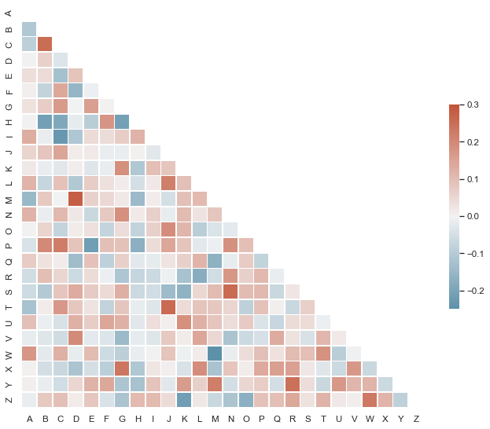

# scatter plot matrix

- this is the scatter plot version of the correlation matrix
- color-coding can be used to add a 3rd dimension
- image source: [seaborn.pydata.org/](https://seaborn.pydata.org/examples/scatterplot_matrix.html)

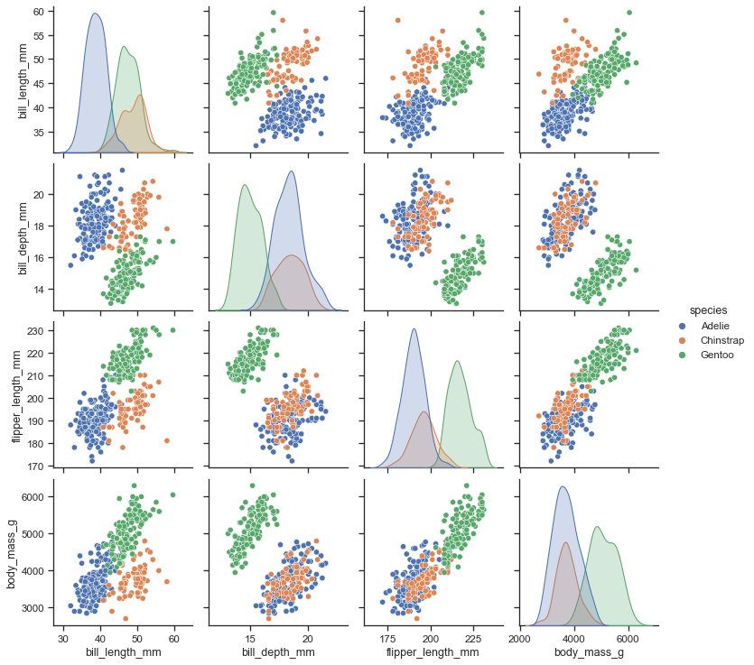

# Spurious correlations

- image source: [tylervigen.com](https://www.tylervigen.com/spurious-correlations)

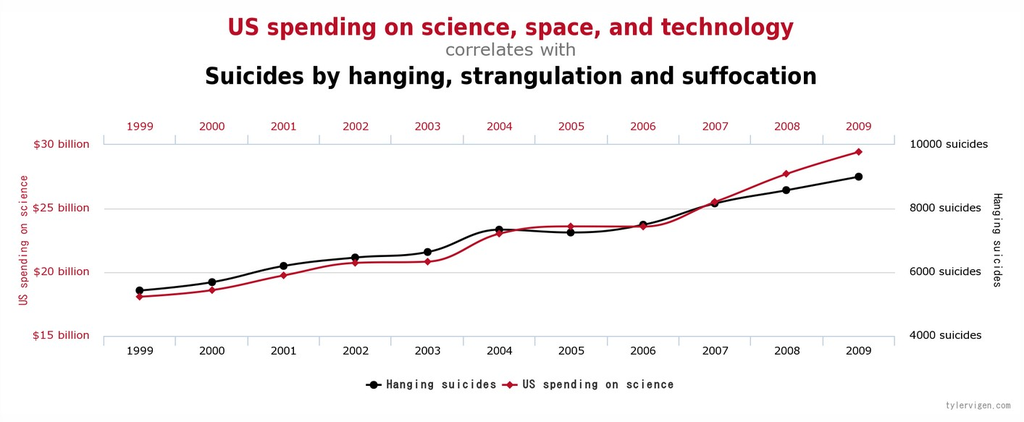

# Simpson’s paradox

Simpson’s paradox gives rise to false associations

- A trend appears to have one trend
- But another trend when data is grouped by another variable
- image source: [wikipedia.com](https://en.wikipedia.org/wiki/Anscombe%27s_quartet)

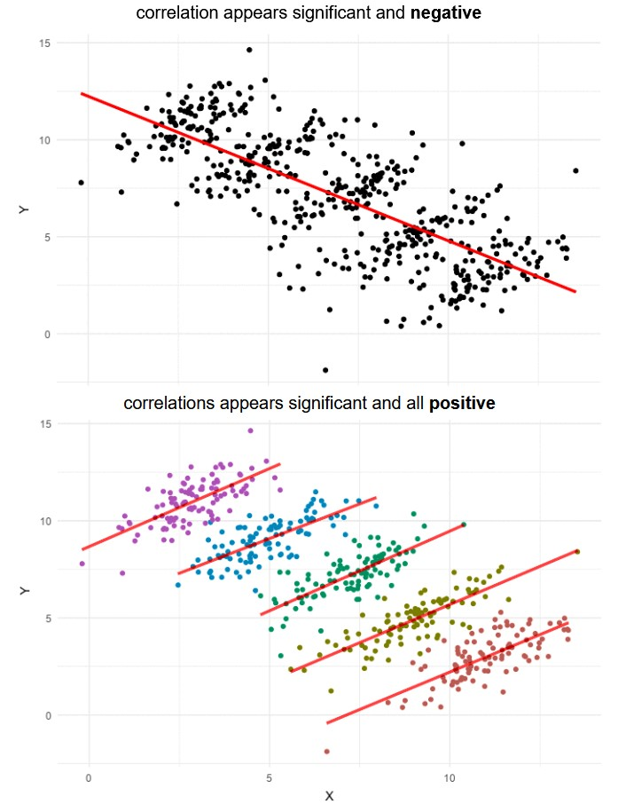

# Simpson’s paradox

Simpson’s paradox arises from a **latent variable**

- Latent variable is ‘hidden’
  - Not considered in an analysis
  - Unobservable or data is unavailable
- Examples of unobservatble data
  - Someone’s intention; only observe actions or responses
  - The presence of a disease; only observe symptoms
  - The temperature of the surface of the sun; only observe spectra

# Simpson’s paradox

With categorical data, Simpson’s paradox can occur when the relative size of the groups is different between the control and treatment

- image source: [theconversation.com](https://theconversation.com/paradoxes-of-probability-and-other-statistical-strangeness-74440)

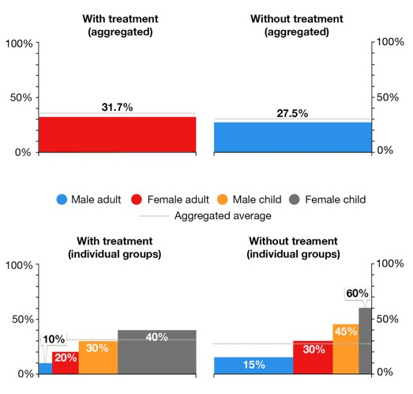

# Anscombe’s quartet

- $x$ and $y$ in the four data sets have the same **mean**, **variance**, **correlation** and **trend line** $y = a + bx$ if we use linear regression to find $a$ and $b$
- image source: [wikipedia.com](https://en.wikipedia.org/wiki/Anscombe%27s_quartet)

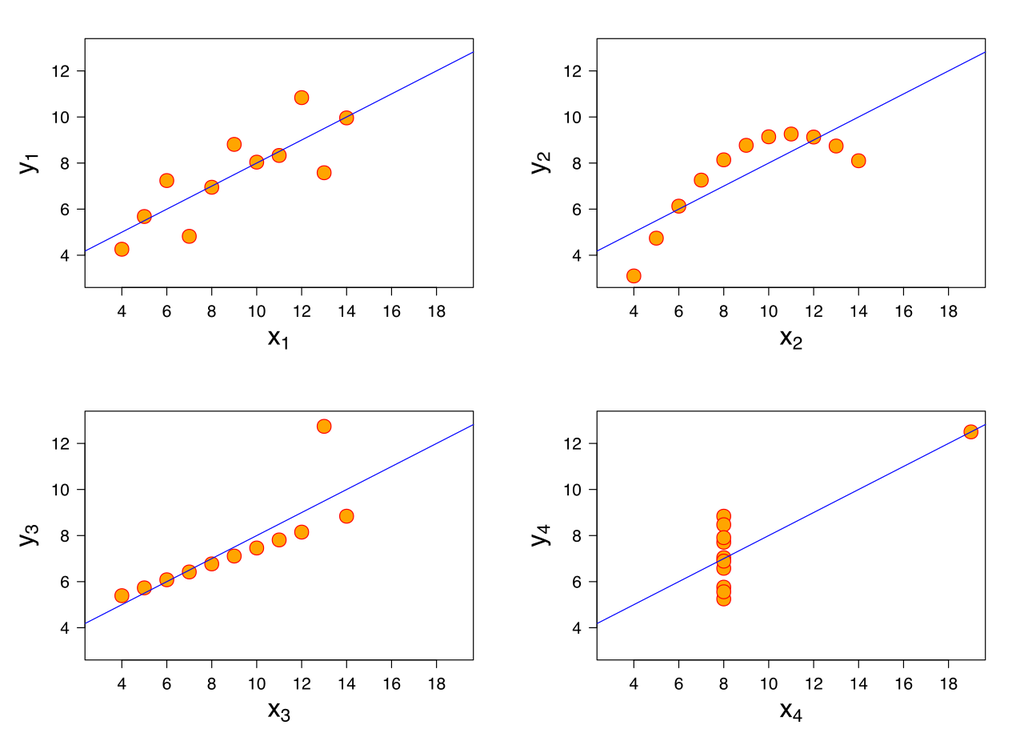